# Introduction of ArcSDE

- `ArcSDE (Spatial Database Engine)` is a software component developed by Esri (Environmental Systems Research Institute) that enables spatial data to be stored in commercial relational database management systems (`RDBMS`) like `Oracle`, `Microsoft SQL Server`, `IBM Db2`, and `PostgreSQL`.
- It acts as a **bridge between the Esri's ArcGIS software suite and the underlying RDBMS**, allowing for efficient storage, retrieval, and management of spatial data within a database environment.

## Framework Diagram:

```
                            +---------------------+
                            |      ArcGIS Client  |
                            |    (Desktop/Pro)    |
                            +----------+----------+
                                       |
                                       |
                                       v
                            +---------------------+
                            |   ArcSDE Client API |
                            +----------+----------+
                                       |
                                       |
                                       v
                            +---------------------+
                            |    ArcSDE Service   |
                            +----------+----------+
                                       |
                                       |
                                       v
                            +---------------------+
                            |      Geodatabase    |
                            |   (RDBMS Backend)   |
                            +---------------------+
```

In this framework:

1. ArcGIS `client` applications interact with `ArcSDE service` through `ArcSDE client API`.
2. `ArcSDE service` manages communication with the geodatabase stored in the RDBMS backend.
3. The geodatabase organizes spatial and attribute data within the RDBMS, providing a unified data management platform for ArcGIS `clients`.

## Connect ArcGIS Desktop with Existing Database Server

1. In your ArcGIS Desktop, insert a connection with database

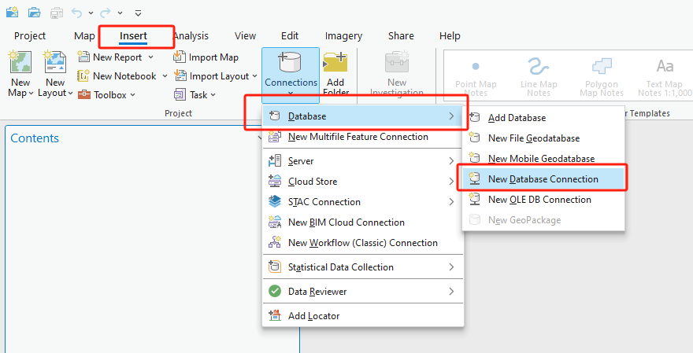

2. Use your credential to access the database

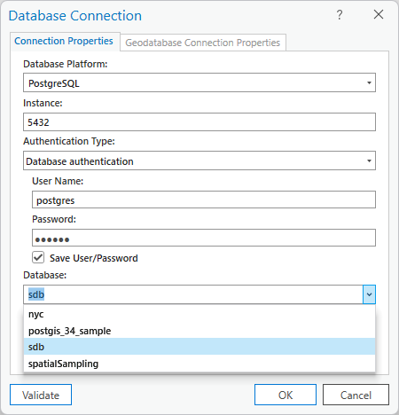

3. Once you established a connection, you can see it in `Catalog`

[figure not shown]

4. When you hove your mouse on the connection, you're able to see the sde file path
   1. you can distribute this file with your co-worker, then they can have the access to the same data as you

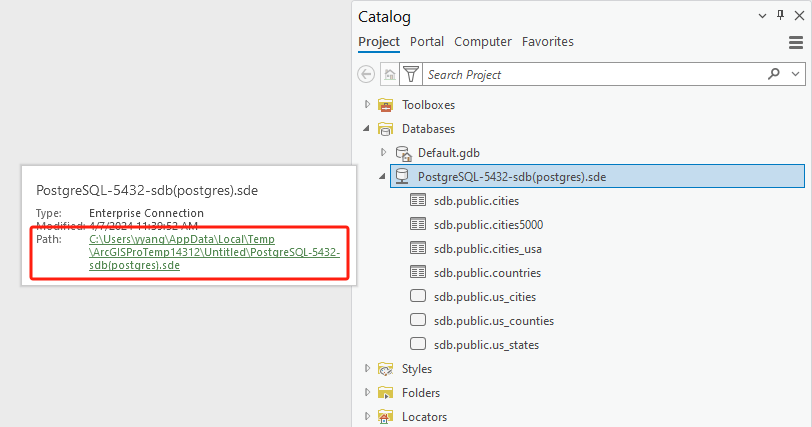

## Versioned Editing in Arc SDE

- [Reference](https://www.youtube.com/watch?v=2bGqYmn-_w4&ab_channel=NGISUniversity)

`Versioned editing` in `ArcSDE` allows multiple users to simultaneously edit geospatial data in a **multi-user editing** environment while maintaining data integrity and avoiding conflicts.

It is particularly useful in scenarios where multiple users need to make changes to the same dataset **concurrently**, such as in enterprise GIS environments or collaborative projects.

1. Create your own version for editing
   1. Right click the database you connected, choose `administration`, `versions`

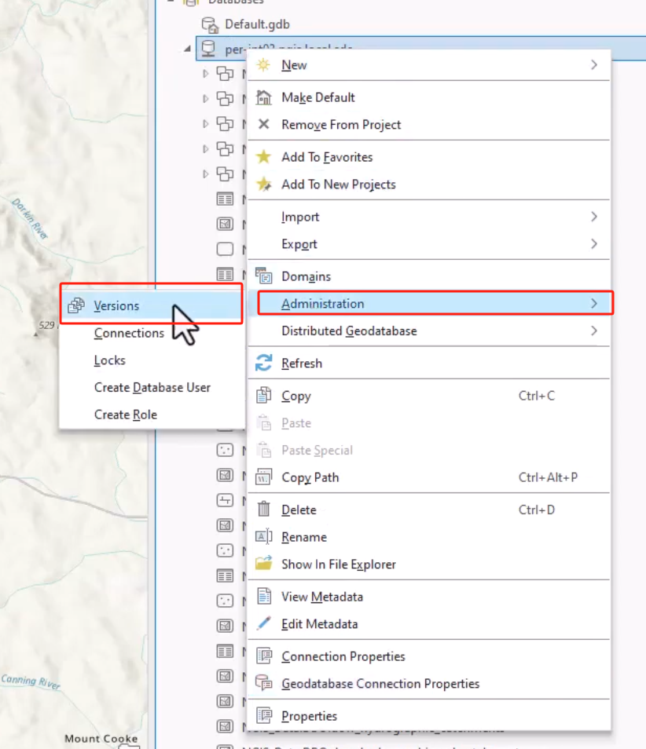

   2. Create your own version with detailed description

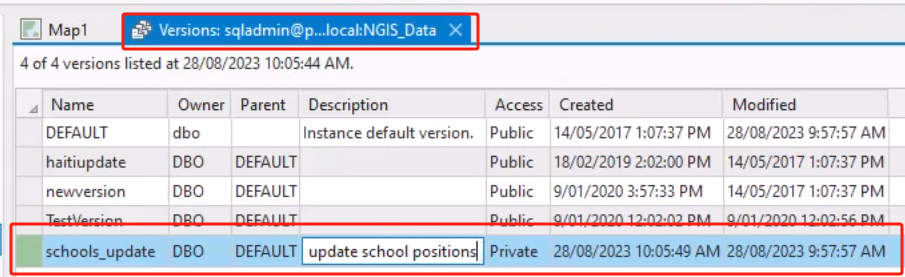

   3. Right click the database connection, choose connection property, switch the `Versioning Type` to the one you just created

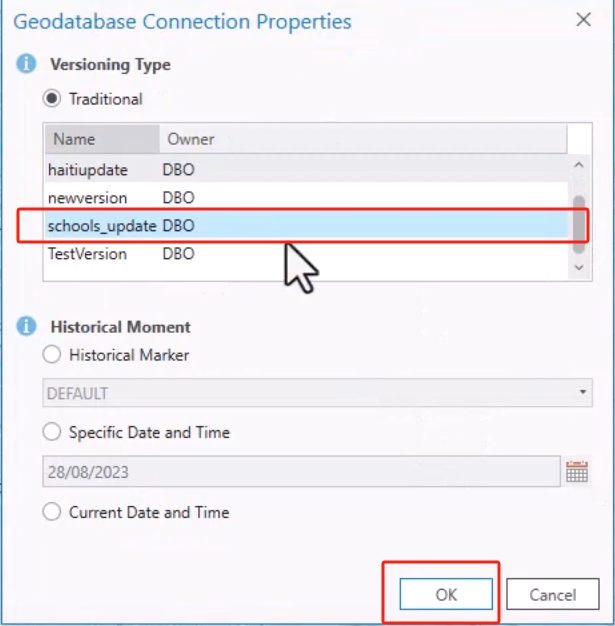

2. do some editing and perform `QA` workflow
3. Push to the source
   1. Go to `administration`, and choose `versions`

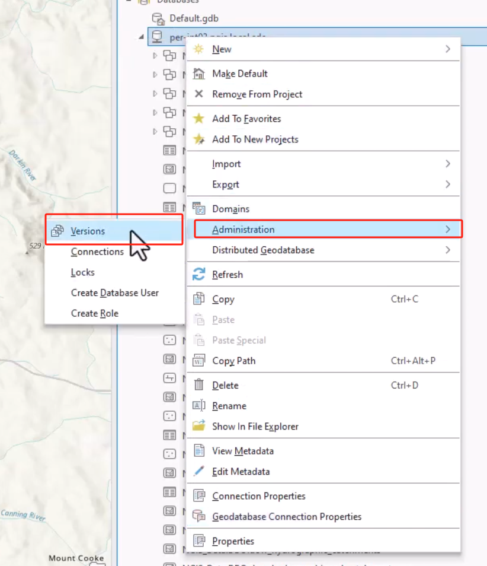

   2. Choose the version you try to push to source, right click it and choose `Reconcile/Post`
   3. Select the `Target Version`, check `Post versions after reconcile`

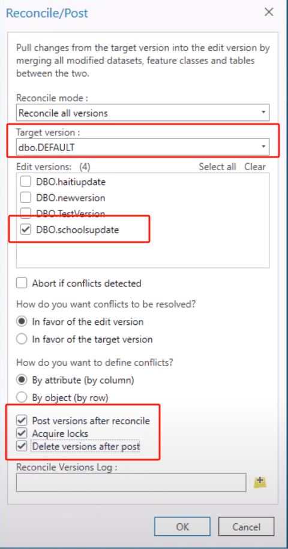

## Publishing to ArcGIS Portal

- [Reference](https://www.youtube.com/watch?v=fz-LYtOLCJY&ab_channel=NGISUniversity)
1. Connect to the portal (Enterprise or ArcGIS Online)

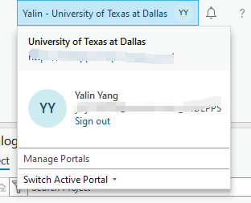

2. Click `Share` in ribbon, and select `Web Map`

[figure not shown]

3. Setup the Web Map property with Access permission
4. Analyze before publish your Web Map to see if any errors
   1. For Map Projection Error, double click it, ArcGIS will automatically solve it for you

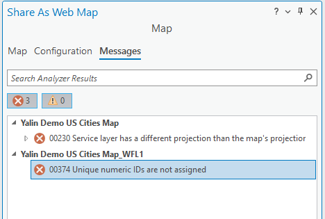

   2. For unique ID problem, double click it and check `allow assigning unique ID for Web Map sharing`

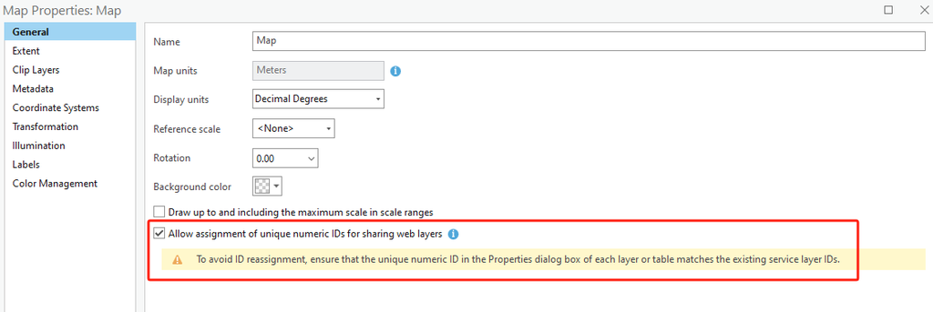

5. Then, click `Share`, you map will be uploaded to the Portal

[figure not shown]

## Using WebApp Builder

1. Go to your Web Map, Create Web App using `Web App Builder`

[figure not shown]

2. Get more information from [official document](https://developers.arcgis.com/web-appbuilder/)
   - Final published version should looks like

[figure not shown]

## Additional Example

[Yalin EIP Program](https://storymaps.arcgis.com/collections/eb998958af064940ac9c472676b6cf05?item=8)

2025-11-20 2025-11-20